# Lincoln County Fact Sheet: Money Bonds

Charlotte McClintock & Sam Powers

Fall 2018

## Incarceration Trends in Lincoln County

## Money Bonds vs. PR Bonds in Lincoln County

Lincoln County has set money bond in over 95% of cases for both felonies and misdemeanor every year for the past three years.

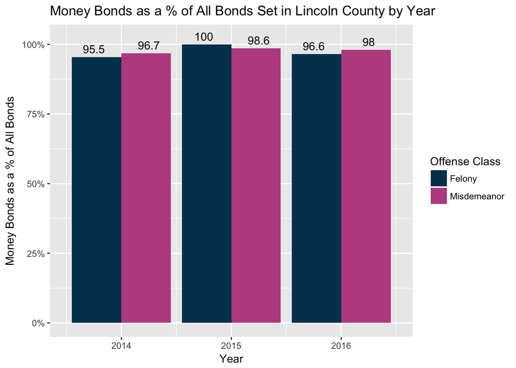

Lincoln County used money bonds more frequently than any other county which processed at least 10 bonds in 2016, for both felony and misdemeanor offenses.

Counties With Highest Percentage Money Bond for Felony Offenses in 2016

| County | Year | Offense Class | Money Bonds as a % of All Bonds | Total Bonds |
| --- | --- | --- | --- | --- |
| Lincoln | 2016 | Felony Offense | 0.97 | 87 |
| El Paso | 2016 | Felony Offense | 0.95 | 6106 |
| Dolores | 2016 | Felony Offense | 0.94 | 17 |
| Eagle | 2016 | Felony Offense | 0.94 | 300 |
| Clear Creek | 2016 | Felony Offense | 0.93 | 86 |
| Summit | 2016 | Felony Offense | 0.93 | 283 |
| Ouray | 2016 | Felony Offense | 0.92 | 24 |
| Gunnison | 2016 | Felony Offense | 0.89 | 115 |
| Montrose | 2016 | Felony Offense | 0.89 | 301 |
| Delta | 2016 | Felony Offense | 0.88 | 129 |

Counties With Highest Percentage Money Bond for Misdemeanor Offenses in 2016

| County | Year | Offense Class | Money Bonds as a % of All Bonds | Total Bonds |
| --- | --- | --- | --- | --- |
| Lincoln | 2016 | Misdemeanor Offense | 0.98 | 397 |
| Kiowa | 2016 | Misdemeanor Offense | 0.95 | 56 |
| Mineral | 2016 | Misdemeanor Offense | 0.95 | 38 |
| Prowers | 2016 | Misdemeanor Offense | 0.95 | 659 |
| Baca | 2016 | Misdemeanor Offense | 0.94 | 112 |
| Las Animas | 2016 | Misdemeanor Offense | 0.92 | 846 |
| Cheyenne | 2016 | Misdemeanor Offense | 0.90 | 79 |
| Delta | 2016 | Misdemeanor Offense | 0.90 | 622 |
| Sedgwick | 2016 | Misdemeanor Offense | 0.90 | 69 |
| Gunnison | 2016 | Misdemeanor Offense | 0.89 | 406 |

Although many counties decreased their use of money bonds after the passage of HB13.1236, Lincoln County actually modestly *increased* use of money bonds.

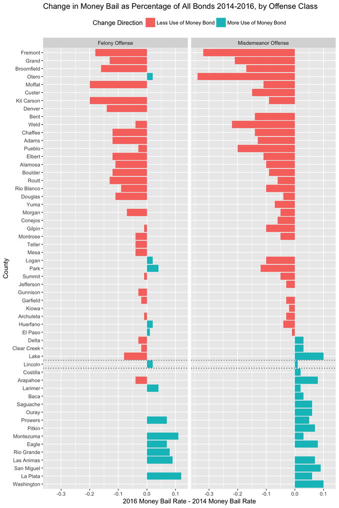

## Incarceration Trends in Lincoln County

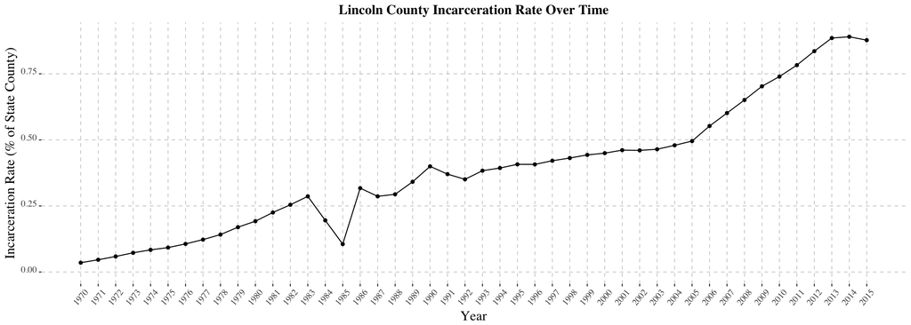

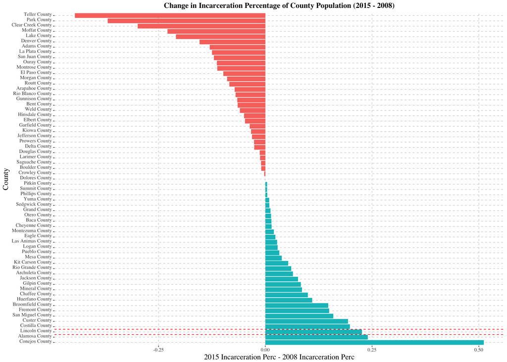

Due to the nature of incarceration as a proportion (Jail Population/County Population), it is affected both by changes in the Jail population and in the County population. This graph breaks all counties into components contributing to incarceration change.

Lincoln county falls into the second quadrant, which means that while the county population has decreased slightly since 2008, the jail population has increased by about 35%.

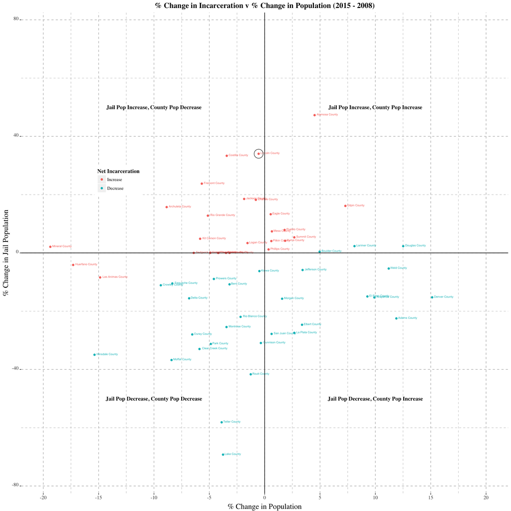